# How Good Are Crystal Generative Models?

Continuous Metrics and Substitution-Based Novelty Analysis

Masahiro Negishi · Future of Materials Design — Singapore, 2026-07-01

[figure not shown]

Slides

# Inverse design using generative models

[figure not shown]

- Sample candidates from larger chemical space
- Optionally condition generation on target properties
- Update the model from screening / synthesis feedback

# Generative models 101

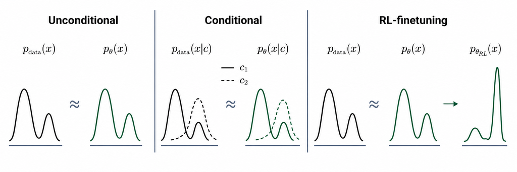

- Once trained, the model generates numerous candidates efficiently.

# Rigorous evaluation is necessary

- Which model is most suitable for a given application?
- Are we heading in the right direction in model development?

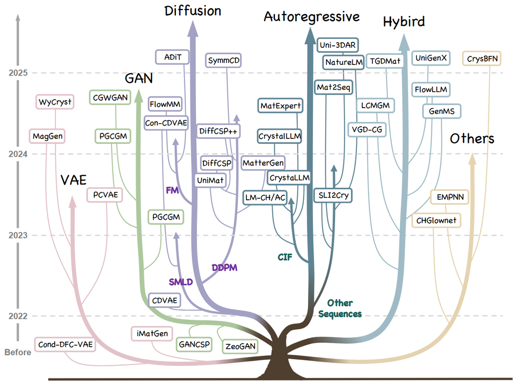

<sup>[1]</sup>

# Two types of evaluation metrics

- Application- / lab-specific requirements
  - Do candidates satisfy the target property?
  - Are candidates synthesizable with your lab's equipment?
- Universal prerequisites ← focus of this talk
  - Do models generate diverse, novel, and stable candidates?

# Three prerequisites

[figure not shown]

# SUN is binary

[figure not shown]

- Highly dependent on heuristic thresholds
- Fails to distinguish marginal passes from strong passes

# Making U and N continuous

## Uniqueness

$\mathrm{U}(x) \in \{0,1\}$:1 if $x$ does not match any preceding generated sample via $\texttt{StructureMatcher}$

$\mathrm{cU}(x) \in [0,1]$:average $d_c$ to the other generated samples

## Novelty

[figure not shown]

$\mathrm{N}(x) \in \{0,1\}$:1 if $x$ does not match any training sample via $\texttt{StructureMatcher}$

$\mathrm{cN}(x) \in [0,1]$:$d_c$ to the nearest training sample

$d_c$ = linear sum of the Average Minimum Distance (structural) and the Element Mover's Distance (compositional). <sup>[2,3]</sup>

# cU and cN better capture sample distributions

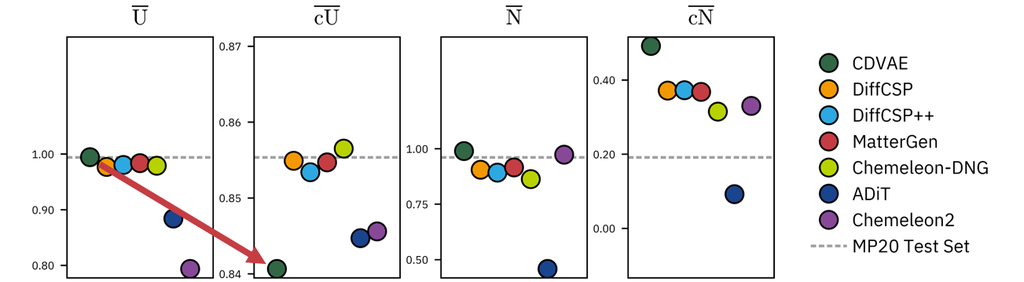

- CDVAE has few exact $\texttt{StructureMatcher}$ duplicates, but is highly concentrated in continuous metric space.
- Best models match MP20-test uniqueness while exceeding its novelty.
- cU and cN also have theoretical advantages (robust to atomic-coordinate perturbations, invariant to sample permutation, etc.)

# Making S continuous

[figure not shown]

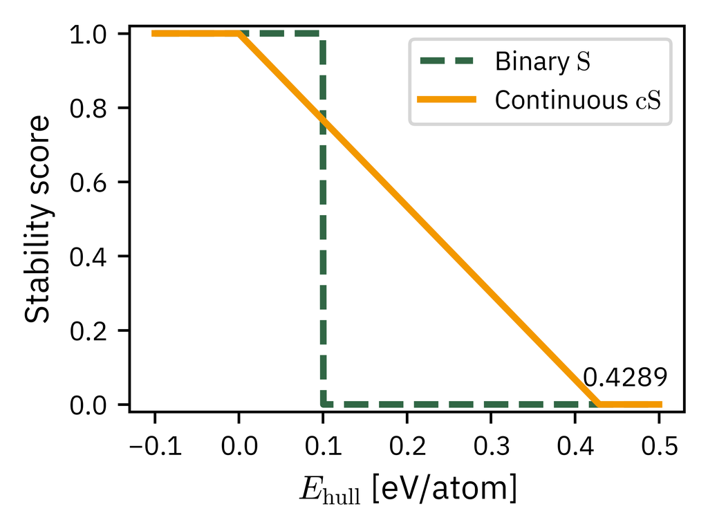

- Binary stability fails to capture the gradation of stability.
- An overly strict binary threshold may filter out all but the most conservative samples.

c.f. ~20% of experimentally synthesized MP crystals satisfy $E_\mathrm{hull} \ge 0.1$ [eV/atom].

# cS offers a smoother score distribution

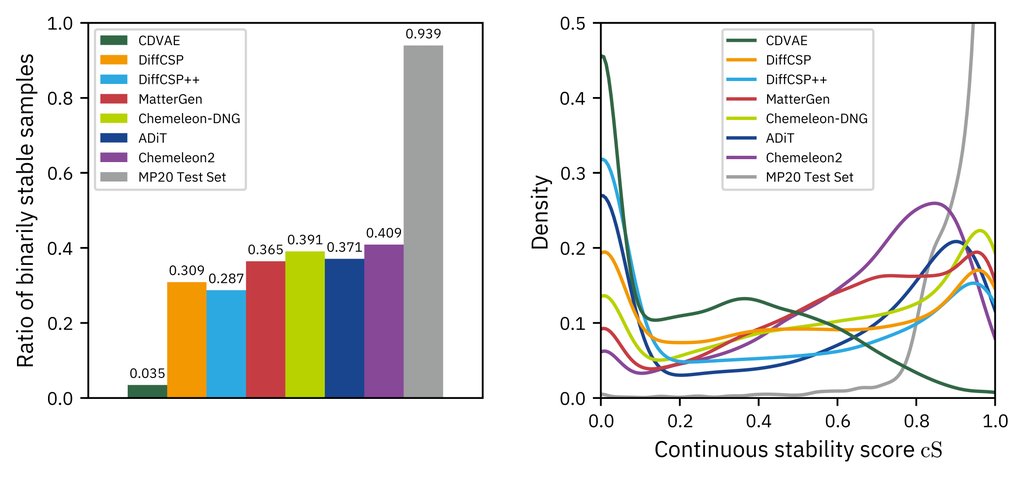

- With cS, fewer samples are merely removed.

# A single unified metric: cSUN

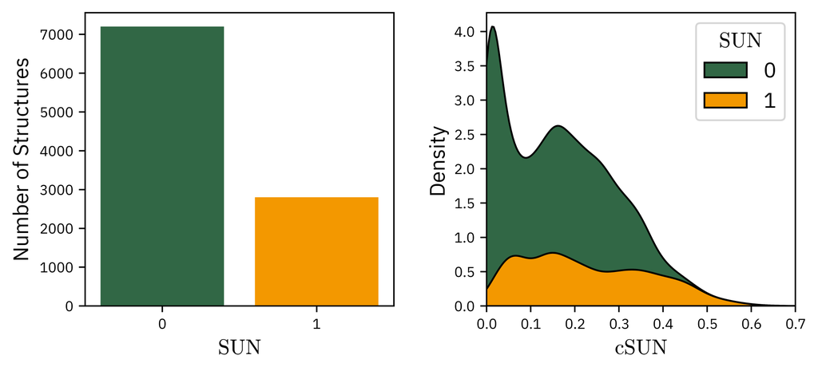

Sun and cSUN scores of MatterGen samples

$\mathrm{SUN}(x) = \mathrm{S}(x)\,\mathrm{U}(x)\,\mathrm{N}(x) \in \{0,1\}$

$\mathrm{cSUN}(x) = \mathrm{cS}(x)^{w_S}\,\mathrm{cU}(x)^{w_U}\,\mathrm{cN}(x)^{w_N} \in [0,1]$

- cSUN offers a detailed ranking of candidates.
- Customizable weights enable the prioritization of specific components over others.

# Customizable weights allow flexible evaluation

- Investigating the S-N tradeoff by setting the weights as below:$(w_S,\, w_U,\, w_N) = (w_S,\, 1,\, 2 - w_S)$
- More weight on stability $\to$ CDVAE $\downarrow$, MP20 test $\uparrow$.
- MatterGen and Chemeleon2 consistently hold the top positions.

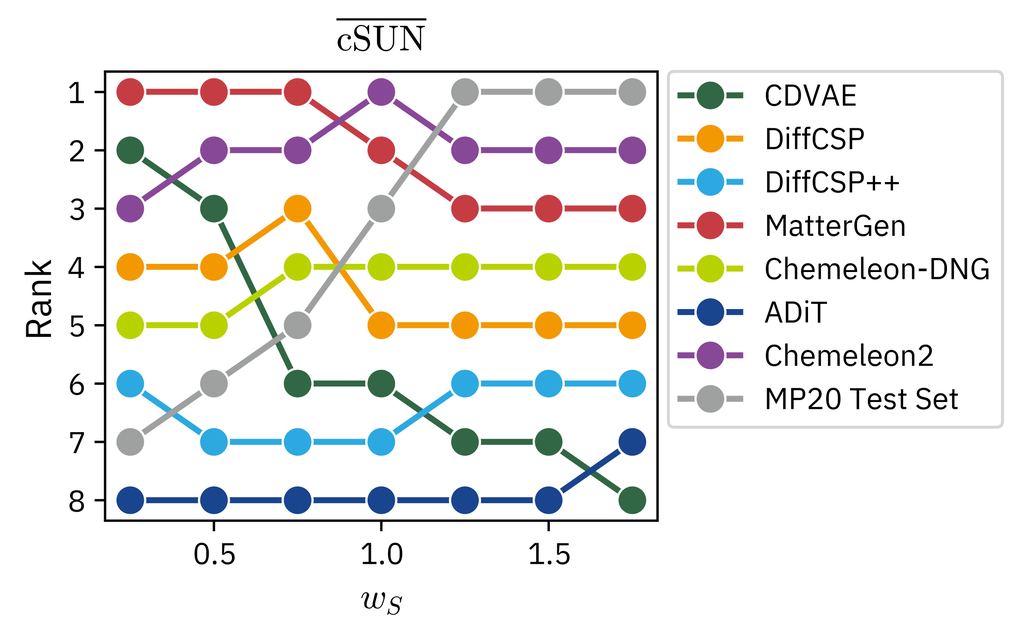